# Data 190: Capstone

## Exploratory Data Analysis for our listing datasets

```python
#Separate categorical and numberical columns
cat_col = all_listing_df.dtypes[all_listing_df.dtypes == 'object']
num_col = all_listing_df.dtypes[all_listing_df.dtypes != 'object']
```

```python
for col in list(cat_col.index):
    print(f"--------------------{col.title()}-------------------------")
    total= all_listing_df[col].value_counts()
    percent = all_listing_df[col].value_counts() / all_listing_df.shape[0]
    df2 = pd.concat([total,percent],keys = ['total','percent'],axis = 1)
    print(df2)
    print('\n')
```

```
--------------------Name-------------------------
                                                    total   percent
The Bartlett QUEEN                                     24  0.001386
Studio at Donatello Hotel near Union Square            15  0.000866
Union Square Convention Hotel                          15  0.000866
Greenleaf Hotel                                        15  0.000866
BARTLETT QUEEN                                         10  0.000578
...                                                   ...       ...
Living room in quiet house near Retro Row & beach       1  0.000058
Private Guesthouse Apartment Hidden in the Hills.       1  0.000058
North Seattle Retreat: Spacious and Bright              1  0.000058
Beautiful Windowsill Garden Studio                      1  0.000058
Chic Jr. Studio Pacific Heights Victorian Home-pvt      1  0.000058

[17100 rows x 2 columns]


--------------------Host_Location-------------------------
                                          total   percent
Los Angeles, California, United States     6810  0.393346
San Francisco, California, United States   2717  0.156934
Seattle, Washington, United States         1941  0.112112
Long Beach, California, United States       581  0.033559
US                                          577  0.033328
...                                         ...       ...
Shenzhen, Guangdong, China                    1  0.000058
Victoria, Australia                           1  0.000058
Chadds Ford, Pennsylvania, United States      1  0.000058
Poulsbo, Washington, United States            1  0.000058
Bass Lake, California, United States          1  0.000058

[510 rows x 2 columns]


--------------------Host_About-------------------------
                                                    total   percent
Why take a chance picking & choosing between so...    106  0.006123
We are a small company in San Francisco that ow...     67  0.003870
Used to be a professor (Ph.D. in Political Econ...     62  0.003581
Husband and father of two, loves travel, hiking...     49  0.002830
```

[output cut: 86 more lines]

```
...                                                   ...       ...
["Refrigerator", "Bed linens", "Microwave", "Co...      1  0.000058
["Washer", "Breakfast", "Dryer", "Heating", "Wi...      1  0.000058
["Wifi", "Dishwasher", "Room-darkening shades",...      1  0.000058
["Room-darkening shades", "Hangers", "Dishwashe...      1  0.000058
["Microwave", "Private entrance", "Smoke alarm"...      1  0.000058

[16800 rows x 2 columns]


--------------------City-------------------------
               total   percent
Los Angeles    11979  0.691908
San Francisco   3195  0.184543
Seattle         2139  0.123549
```

```python
for col in list(num_col.index):
    print(f"--------------------{col.title()}-------------------------")
    total= all_listing_df[col].value_counts()
    percent = all_listing_df[col].value_counts() / all_listing_df.shape[0]
    df2 = pd.concat([total,percent],keys = ['total','percent'],axis = 1)
    print(df2)
    print('\n')
```

```
--------------------Id-------------------------
          total   percent
47908863      1  0.000058
45238892      1  0.000058
32500360      1  0.000058
7113348       1  0.000058
10269315      1  0.000058
...         ...       ...
23907555      1  0.000058
31466261      1  0.000058
14746690      1  0.000058
13698266      1  0.000058
14913538      1  0.000058

[17313 rows x 2 columns]


--------------------Host_Since-------------------------
            total   percent
2016-12-16    116  0.006700
2012-12-17     87  0.005025
2012-07-27     74  0.004274
2017-08-23     58  0.003350
2016-05-06     55  0.003177
...           ...       ...
2019-05-09      1  0.000058
2018-09-28      1  0.000058
2014-12-14      1  0.000058
2015-11-28      1  0.000058
2016-11-22      1  0.000058

[3381 rows x 2 columns]


--------------------Host_Response_Rate-------------------------
       total   percent
100.0  10302  0.595044
90.0     395  0.022815
97.0     252  0.014556
94.0     210  0.012130
```

[output cut: 458 more lines]

```
9.0    5654  0.326575
8.0     748  0.043205
0.0     272  0.015711
7.0     112  0.006469
6.0     108  0.006238
2.0      41  0.002368
4.0      23  0.001328
5.0      14  0.000809
3.0       2  0.000116


--------------------Instant_Bookable-------------------------
   total   percent
0  11702  0.675908
1   5611  0.324092
```

## Time series

Question: how long have hosts been listing properties on Airbnb?

```python
print(f"Of the Airbnb hosts that are still listing on the site, the first joined on {min(all_listing_df.host_since).strftime('%d %B %Y')}, and the most recent joined on {max(all_listing_df.host_since).strftime('%d %B %Y')}.")
```

```
Of the Airbnb hosts that are still listing on the site, the first joined on 31 July 2008, and the most recent joined on 02 February 2021.
```

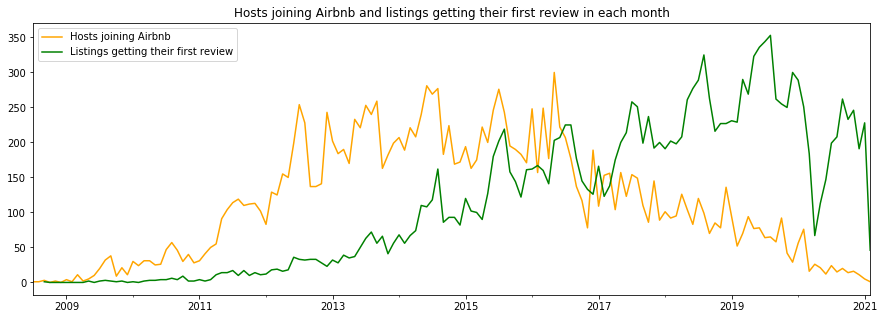

```python
plt.figure(figsize=(15,5))
all_listing_df.set_index('host_since').resample('MS').size().plot(label='Hosts joining Airbnb', color='orange')
all_listing_df.set_index('first_review').resample('MS').size().plot(label='Listings getting their first review', color='green')
plt.title('Hosts joining Airbnb and listings getting their first review in each month')
plt.legend()
plt.xlim('2008-07-31', '2021-02-02') # Limiting to whole months
plt.xlabel('')
plt.ylabel('')
plt.show()
```

```python
# Creating dataframes for time series analysis
ts_host_since = pd.DataFrame(all_listing_df.set_index('host_since').resample('MS').size())
ts_first_review = pd.DataFrame(all_listing_df.set_index('first_review').resample('MS').size())

# Renaming columns
ts_host_since = ts_host_since.rename(columns={0: 'hosts'})
ts_host_since.index.rename('month', inplace=True)
ts_first_review = ts_first_review.rename(columns={0: 'reviews'})
ts_first_review.index.rename('month', inplace=True)
```

```python
def decompose_time_series(all_listing_df, title=''):
    """
    Plots the original time series and its decomposition into trend, seasonal and residual.
    """
    # Decomposing the time series
    decomposition = seasonal_decompose(all_listing_df)

    # Getting the trend, seasonality and noise
    trend = decomposition.trend
    seasonal = decomposition.seasonal
    residual = decomposition.resid

    # Plotting the original time series and the decomposition
    plt.figure(figsize=(12,8))
    plt.suptitle(title, fontsize=14, y=1)
    plt.subplots_adjust(top=0.80)
    plt.subplot(411)
    plt.plot(all_listing_df, label='Original')
    plt.legend(loc='upper left')
    plt.subplot(412)
    plt.plot(trend, label='Trend')
    plt.legend(loc='upper left')
    plt.subplot(413)
    plt.plot(seasonal,label='Seasonality')
    plt.legend(loc='upper left')
    plt.subplot(414)
    plt.plot(residual, label='Residuals')
    plt.legend(loc='upper left')
    plt.tight_layout()
```

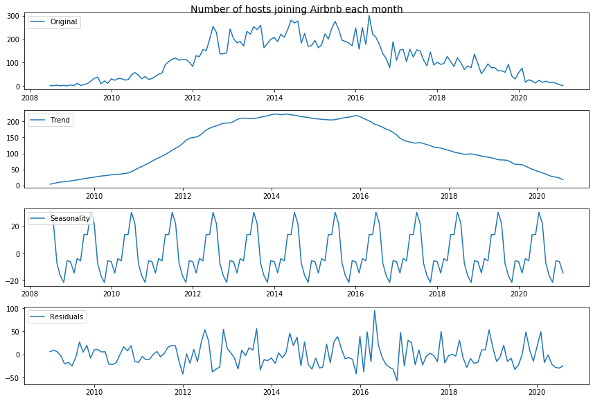

```python
from statsmodels.tsa.seasonal import seasonal_decompose

decompose_time_series(ts_host_since, title='Number of hosts joining Airbnb each month')
```

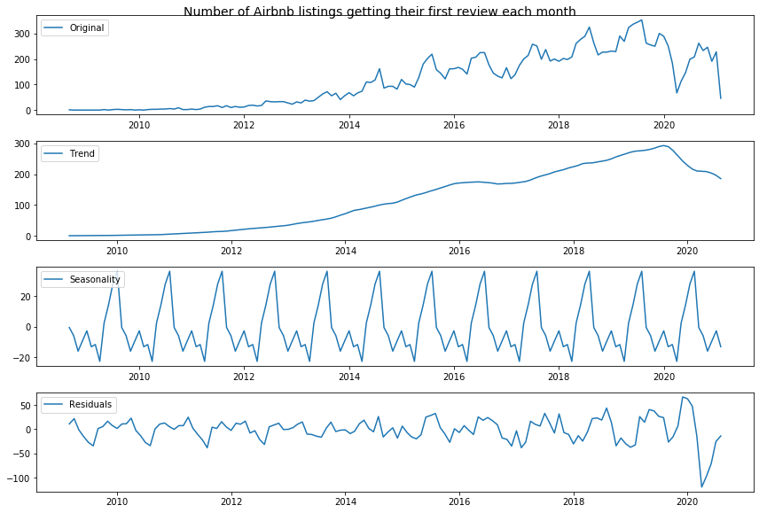

```python
decompose_time_series(ts_first_review, title='Number of Airbnb listings getting their first review each month')
```

Question: how have prices changed over time?

[figure not shown]

```python
plt.figure(figsize=(16,6))
sns.boxplot(all_listing_df.first_review.dt.year, np.log(all_listing_df.price))
plt.xlabel('Year that the listing had its first review', fontsize=12)
plt.ylabel('Nightly price (log-transformed)', fontsize=12)
plt.title('Change per year in the nightly price of Airbnb listings in London', fontsize=16)
plt.show()
```

```python
print("Mean nightly price of listings in each year on Airbnb:")
print(round(all_listing_df.set_index('first_review').price.resample('YS').mean(),2))
```

```
Mean nightly price of listings in each year on Airbnb:
first_review
2008-01-01    296.00
2009-01-01    105.92
2010-01-01    137.12
2011-01-01    142.09
2012-01-01    172.25
2013-01-01    202.27
2014-01-01    164.61
2015-01-01    162.59
2016-01-01    168.36
2017-01-01    179.98
2018-01-01    170.00
2019-01-01    172.92
2020-01-01    204.00
2021-01-01    258.45
Freq: AS-JAN, Name: price, dtype: float64
```

```python
# Dropping host_since and first_review as they are no longer needed
all_listing_df.drop(['host_since', 'first_review'], axis=1, inplace=True)
```

## Numerical features

```python
all_listing_df.describe()
```

|  | id | host_response_rate | host_is_superhost | latitude | longitude | accommodates | bedrooms | beds | price | minimum_nights | ... | availability_365 | number_of_reviews | review_scores_rating | review_scores_accuracy | review_scores_cleanliness | review_scores_checkin | review_scores_communication | review_scores_location | review_scores_value | instant_bookable |
| --- | --- | --- | --- | --- | --- | --- | --- | --- | --- | --- | --- | --- | --- | --- | --- | --- | --- | --- | --- | --- | --- |
| count | 1.731300e+04 | 13288.000000 | 17313.000000 | 17313.000000 | 17313.000000 | 17313.000000 | 17313.000000 | 17313.000000 | 17313.000000 | 17313.000000 | ... | 17313.000000 | 17313.00000 | 17313.00000 | 17313.000000 | 17313.000000 | 17313.000000 | 17313.000000 | 17313.000000 | 17313.000000 | 17313.000000 |
| mean | 2.199703e+07 | 95.192881 | 0.485820 | 36.411104 | -119.574609 | 3.553168 | 1.524461 | 1.949980 | 177.540172 | 16.457749 | ... | 170.918154 | 65.43089 | 95.16814 | 9.581008 | 9.432623 | 9.691157 | 9.668688 | 9.612488 | 9.353780 | 0.324092 |
| std | 1.413510e+07 | 15.770664 | 0.499813 | 4.444758 | 1.885636 | 2.376639 | 0.931140 | 1.519906 | 278.239857 | 33.084137 | ... | 137.924067 | 89.72572 | 9.42780 | 1.388048 | 1.418204 | 1.340952 | 1.366046 | 1.358064 | 1.426983 | 0.468048 |
| min | 9.580000e+02 | 0.000000 | 0.000000 | 33.339090 | -122.511630 | 1.000000 | 1.000000 | 0.000000 | 10.000000 | 1.000000 | ... | 0.000000 | 1.00000 | 0.00000 | 0.000000 | 0.000000 | 0.000000 | 0.000000 | 0.000000 | 0.000000 | 0.000000 |
| 25% | 9.052529e+06 | 100.000000 | 0.000000 | 34.033120 | -122.329150 | 2.000000 | 1.000000 | 1.000000 | 75.000000 | 2.000000 | ... | 35.000000 | 7.00000 | 94.00000 | 10.000000 | 9.000000 | 10.000000 | 10.000000 | 10.000000 | 9.000000 | 0.000000 |
| 50% | 2.156215e+07 | 100.000000 | 0.000000 | 34.102780 | -118.409000 | 3.000000 | 1.000000 | 1.000000 | 115.000000 | 4.000000 | ... | 160.000000 | 29.00000 | 98.00000 | 10.000000 | 10.000000 | 10.000000 | 10.000000 | 10.000000 | 10.000000 | 0.000000 |
| 75% | 3.397252e+07 | 100.000000 | 1.000000 | 37.754880 | -118.287690 | 4.000000 | 2.000000 | 2.000000 | 185.000000 | 30.000000 | ... | 319.000000 | 88.00000 | 100.00000 | 10.000000 | 10.000000 | 10.000000 | 10.000000 | 10.000000 | 10.000000 | 1.000000 |
| max | 4.823381e+07 | 100.000000 | 1.000000 | 47.733320 | -117.699750 | 16.000000 | 11.000000 | 50.000000 | 10000.000000 | 1125.000000 | ... | 365.000000 | 959.00000 | 100.00000 | 10.000000 | 10.000000 | 10.000000 | 10.000000 | 10.000000 | 10.000000 | 1.000000 |

8 rows × 25 columns

Price Question: what is the overall distribution of prices?

Answer: nightly advertised prices range from $10 to $10000. The extreme ends of the range are due to hosts not understanding how to use Airbnb advertised prices (sometimes called 'sticker' prices) correctly. The advertised prices can be set to any arbitrary amount, and these are the prices that show when dates are not entered on the site. A model is only as good as its data, and unfortunately this model will be predicting advertised prices rather than the prices actually paid.

```python
print(f"Nightly advertised prices range from ${min(all_listing_df.price)} to ${max(all_listing_df.price)}.")
```

```
Nightly advertised prices range from $10 to $10000.
```

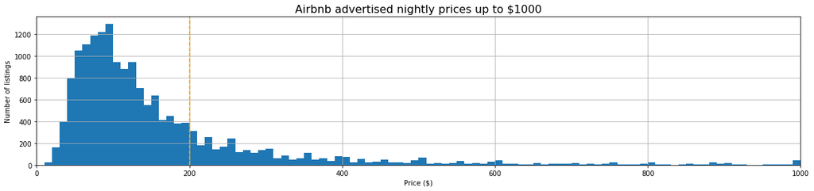

```python
# Distribution of prices from $10 to $1000
plt.figure(figsize=(20,4))
all_listing_df.price.hist(bins=100, range=(0,1000))
plt.margins(x=0)
plt.axvline(200, color='orange', linestyle='--')
plt.title("Airbnb advertised nightly prices up to $1000", fontsize=16)
plt.xlabel("Price ($)")
plt.ylabel("Number of listings")
plt.show()
```

[figure not shown]

```python
# Distribution of prices from $200 upwards
plt.figure(figsize=(20,4))
all_listing_df.price.hist(bins=100, range=(200, max(all_listing_df.price)))
plt.margins(x=0)
plt.axvline(500, color='orange', linestyle='--')
plt.axvline(1000, color='red', linestyle='--')
plt.title("Airbnb advertised nightly prices up to $1000", fontsize=16)
plt.xlabel("Price ($)")
plt.ylabel("Number of listings")
plt.show()
```

Number of people accommodated, bedrooms and beds

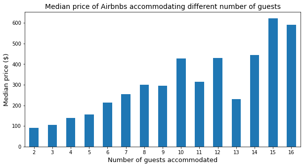

```python
plt.figure(figsize=(10,5))
all_listing_df.groupby('accommodates').price.median().plot(kind='bar')
plt.title('Median price of Airbnbs accommodating different number of guests', fontsize=14)
plt.xlabel('Number of guests accommodated', fontsize=13)
plt.ylabel('Median price ($)', fontsize=13)
plt.xticks(rotation=0)
plt.xlim(left=0.5)
plt.show()
```

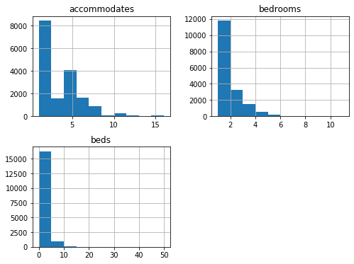

```python
all_listing_df[['accommodates','bedrooms', 'beds']].hist(figsize=(8,6));
```